# Assignment 5: Part 1

*How to do it?*:

- Open the Rmarkdown file of this assignment (link) in Rstudio.
- Right under each **question**, insert a code chunk (you can use the hotkey `Ctrl + Alt + I` to add a code chunk) and code the solution for the question.
- `Knit` the rmarkdown file (hotkey: `Ctrl + Alt + K`) to export an html.
- Publish the html file to your Githiub Page.

*Submission*: Submit the link on Github of the assignment to Canvas.

**The data:**

This assignment works with the Adult Census Data that can be downloaded at [this link.](https://bryantstats.github.io/math421/data/adult_census_missing.csv)

**Questions**

1. Use `read_csv` to import the data. Show the number of NAs for each columns.

```r
library(tidyverse)
df <- read_csv("https://bryantstats.github.io/math421/data/adult_census_missing.csv")
df
```

```
## # A tibble: 32,561 × 15
##      age workclass   fnlwgt education    education.num marital.status occupation
##    <dbl> <chr>        <dbl> <chr>                <dbl> <chr>          <chr>
##  1    90 ?            77053 HS-grad                  9 Widowed        ?
##  2    82 Private     132870 HS-grad                  9 Widowed        Exec-mana…
##  3    66 ?           186061 Some-college            10 Widowed        ?
##  4    54 Private     140359 7th-8th                  4 Divorced       Machine-o…
##  5    41 Private     264663 Some-college            10 Separated      Prof-spec…
##  6    34 Private     216864 HS-grad                  9 Divorced       Other-ser…
##  7    38 Private     150601 10th                     6 Separated      Adm-cleri…
##  8    74 State-gov    88638 Doctorate               16 Never-married  Prof-spec…
##  9    68 Federal-gov 422013 HS-grad                  9 Divorced       Prof-spec…
## 10    41 Private      70037 Some-college            10 Never-married  Craft-rep…
## # ℹ 32,551 more rows
## # ℹ 8 more variables: relationship <chr>, race <chr>, sex <chr>,
## #   capital.gain <dbl>, capital.loss <dbl>, hours.per.week <dbl>,
## #   native.country <chr>, income <chr>
```

```r
colSums(is.na(df))
```

```
##            age      workclass         fnlwgt      education  education.num
##             30             34              0             15              0
## marital.status     occupation   relationship           race            sex
##             26             35              0              0             24
##   capital.gain   capital.loss hours.per.week native.country         income
##              8              0              0             15              0
```

2. Using function `aggr` the VIM package to plot the number of NAs for each column.

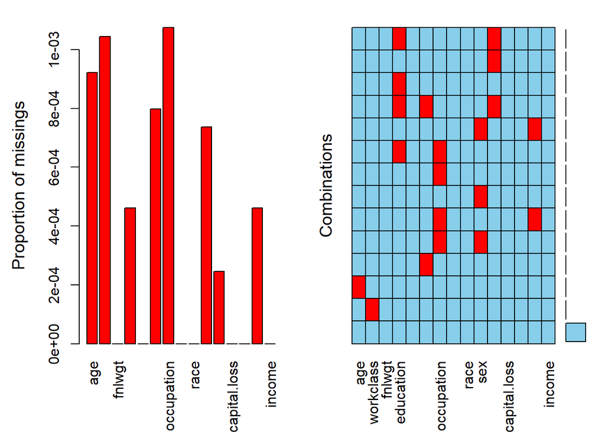

```r
library(VIM)

aggr(df)
```

3. Find other forms of missing values. Hint: You can use the `table` function to check if there are suspicious categories (Unknown, for example) in a variable. What all other forms of missing values shown in the data.

```r
table(df$age)
```

```
##
##  17  18  19  20  21  22  23  24  25  26  27  28  29  30  31  32  33  34  35  36
## 395 550 710 753 718 765 877 796 840 785 832 867 813 860 885 828 875 884 875 897
##  37  38  39  40  41  42  43  44  45  46  47  48  49  50  51  52  53  54  55  56
## 858 827 816 794 808 779 770 724 734 736 707 541 577 602 595 478 462 415 419 365
##  57  58  59  60  61  62  63  64  65  66  67  68  69  70  71  72  73  74  75  76
## 358 366 354 312 300 256 230 208 178 150 151 120 108  89  72  67  64  51  45  46
##  77  78  79  80  81  82  83  84  85  86  87  88  90
##  28  23  22  22  20  12   6  10   3   1   1   3  43
```

```r
table(df$workclass)
```

```
##
##                ?      Federal-gov        Local-gov     Never-worked
##             1835              957             2086                7
##        Not Known          Private     Self-emp-inc Self-emp-not-inc
##               12            22664             1110             2537
##        State-gov          Unknown      Without-pay
##             1293               12               14
```

```r
table(df$education)
```

```
##
##         10th         11th         12th      1st-4th      5th-6th      7th-8th
##          931         1174          431          168          333          645
##          9th   Assoc-acdm    Assoc-voc    Bachelors    Doctorate      HS-grad
##          514         1064         1376         5342          413        10475
##      Masters    Not Known    Preschool  Prof-school Some-college      Unknown
##         1719           36           51          575         7273           26
```

```r
table(df$education.num)
```

```
##
##     1     2     3     4     5     6     7     8     9    10    11    12    13
##    51   168   333   646   514   933  1175   433 10501  7291  1382  1067  5355
##    14    15    16
##  1723   576   413
```

```r
table(df$marital.status)
```

```
##
##              Divorced     Married-AF-spouse    Married-civ-spouse
##                  4435                    23                 14963
## Married-spouse-absent         Never-married             Not Known
##                   418                 10666                    12
##             Separated               Widowed
##                  1025                   993
```

```r
table(df$occupation)
```

```
##
##                 ?      Adm-clerical      Armed-Forces      Craft-repair
##              1840              3761                 9              4090
##   Exec-managerial   Farming-fishing Handlers-cleaners Machine-op-inspct
##              4059               993              1368              2001
##         Not Known     Other-service   Priv-house-serv    Prof-specialty
##                12              3287               149              4132
##   Protective-serv             Sales      Tech-support  Transport-moving
##               647              3647               924              1594
##           Unknown
##                13
```

```r
table(df$relationship)
```

```
##
##        Husband  Not-in-family      Not Known Other-relative      Own-child
##          13164           8287             48            979           5054
##        Unknown      Unmarried           Wife
##             26           3439           1564
```

```r
table(df$race)
```

```
##
## Amer-Indian-Eskimo Asian-Pac-Islander              Black              Other
##                311               1039               3124                271
##              White
##              27816
```

```r
table(df$sex)
```

```
##
##  Female    Male Unknown
##   10752   21759      26
```

```r
table(df$capital.gain)
```

```
##
##     0   114   401   594   914   991  1055  1086  1111  1151  1173  1409  1424
## 29841     6     2    34     8     5    25     4     1     8     3     7     3
##  1455  1471  1506  1639  1797  1831  1848  2009  2036  2050  2062  2105  2174
##     1     7    15     1     7     7     6     3     4     5     2     9    48
##  2176  2202  2228  2290  2329  2346  2354  2387  2407  2414  2463  2538  2580
##    23    16     5     5     6     6    11     1    19     8    11     1    12
##  2597  2635  2653  2829  2885  2907  2936  2961  2964  2977  2993  3103  3137
##    20    11     5    31    24    11     3     3     9     8     2    97    37
##  3273  3325  3411  3418  3432  3456  3464  3471  3674  3781  3818  3887  3908
##     6    53    24     5     4     2    23     8    14    12     7     6    32
##  3942  4064  4101  4386  4416  4508  4650  4687  4787  4865  4931  4934  5013
##    14    42    20    70    12    12    41     3    23    17     1     7    69
##  5060  5178  5455  5556  5721  6097  6360  6418  6497  6514  6723  6767  6849
##     1    97    11     5     3     1     3     9    11     5     2     5    27
##  7298  7430  7443  7688  7896  7978  8614  9386  9562 10520 10566 10605 11678
##   246     9     5   284     3     1    55    22     4    43     6    12     2
## 13550 14084 14344 15020 15024 15831 18481 20051 22040 25124 25236 27828 34095
##    27    41    26     5   347     6     2    37     1     4    11    34     5
## 41310 99999
##     2   159
```

```r
table(df$capital.loss)
```

```
##
##     0   155   213   323   419   625   653   810   880   974  1092  1138  1258
## 31042     1     4     3     3    12     3     2     6     2     7     2     4
##  1340  1380  1408  1411  1485  1504  1539  1564  1573  1579  1590  1594  1602
##     7     7    21     1    51    18     1    25     6    20    40     8    47
##  1617  1628  1648  1651  1668  1669  1672  1719  1721  1726  1735  1740  1741
##     9    15     2     9     4    24    34    22    18     4     2    42    24
##  1755  1762  1816  1825  1844  1848  1876  1887  1902  1944  1974  1977  1980
##     2    14     2     4     1    51    39   159   202     1    18   168    23
##  2001  2002  2042  2051  2057  2080  2129  2149  2163  2174  2179  2201  2205
##    24    21     9    21     6     1     3     2     1     7    15     1     9
##  2206  2231  2238  2246  2258  2267  2282  2339  2352  2377  2392  2415  2444
##     6     3     2     6    25     3     1    17     2    20     9    49    12
##  2457  2467  2472  2489  2547  2559  2603  2754  2824  3004  3683  3770  3900
##     3     1     1     1     4    12     5     2    10     2     2     2     2
##  4356
##     3
```

```r
table(df$hours.per.week)
```

```
##
##     1     2     3     4     5     6     7     8     9    10    11    12    13
##    20    32    39    54    60    64    26   145    18   278    11   173    23
##    14    15    16    17    18    19    20    21    22    23    24    25    26
##    34   404   205    29    75    14  1224    24    44    21   252   674    30
##    27    28    29    30    31    32    33    34    35    36    37    38    39
##    30    86     7  1149     5   266    39    28  1297   220   149   476    38
##    40    41    42    43    44    45    46    47    48    49    50    51    52
## 15217    36   219   151   212  1824    82    49   517    29  2819    13   138
##    53    54    55    56    57    58    59    60    61    62    63    64    65
##    25    41   694    97    17    28     5  1475     2    18    10    14   244
##    66    67    68    70    72    73    74    75    76    77    78    80    81
##    17     4    12   291    71     2     1    66     3     6     8   133     3
##    82    84    85    86    87    88    89    90    91    92    94    95    96
##     1    45    13     2     1     2     2    29     3     1     1     2     5
##    97    98    99
##     2    11    85
```

```r
table(df$native.country)
```

```
##
##                          ?                   Cambodia
##                        582                         19
##                     Canada                      China
##                        121                         75
##                   Columbia                       Cuba
##                         59                         95
##         Dominican-Republic                    Ecuador
##                         70                         27
##                El-Salvador                    England
##                        106                         90
##                     France                    Germany
##                         29                        136
##                     Greece                  Guatemala
##                         29                         64
##                      Haiti         Holand-Netherlands
##                         44                          1
##                   Honduras                       Hong
##                         13                         20
##                    Hungary                      India
##                         13                        100
##                       Iran                    Ireland
##                         43                         24
##                      Italy                    Jamaica
##                         73                         81
##                      Japan                       Laos
##                         62                         18
##                     Mexico                  Nicaragua
##                        642                         34
##                  Not Known Outlying-US(Guam-USVI-etc)
##                         24                         14
##                       Peru                Philippines
##                         31                        198
##                     Poland                   Portugal
##                         60                         37
##                Puerto-Rico                   Scotland
##                        114                         12
##                      South                     Taiwan
##                         80                         51
##                   Thailand            Trinadad&Tobago
##                         18                         18
##              United-States                    Unknown
##                      29110                         26
##                    Vietnam                 Yugoslavia
##                         67                         16
```

```r
table(df$income)
```

```
##
## <=50K  >50K
## 24720  7841
```

**The other forms of NAs are ?, Unknown, and Not Known.**

4. Replace all the forms of missing values found to NA

```r
df <- replace(df, df == 'Unknown' |
                  df == '?' |
                  df == 'Not Known', NA)
```

5. Replot the number of NAs for each column.

```r
colSums(is.na(df))
```

```
##            age      workclass         fnlwgt      education  education.num
##             30           1893              0             77              0
## marital.status     occupation   relationship           race            sex
##             38           1900             74              0             50
##   capital.gain   capital.loss hours.per.week native.country         income
##              8              0              0            647              0
```

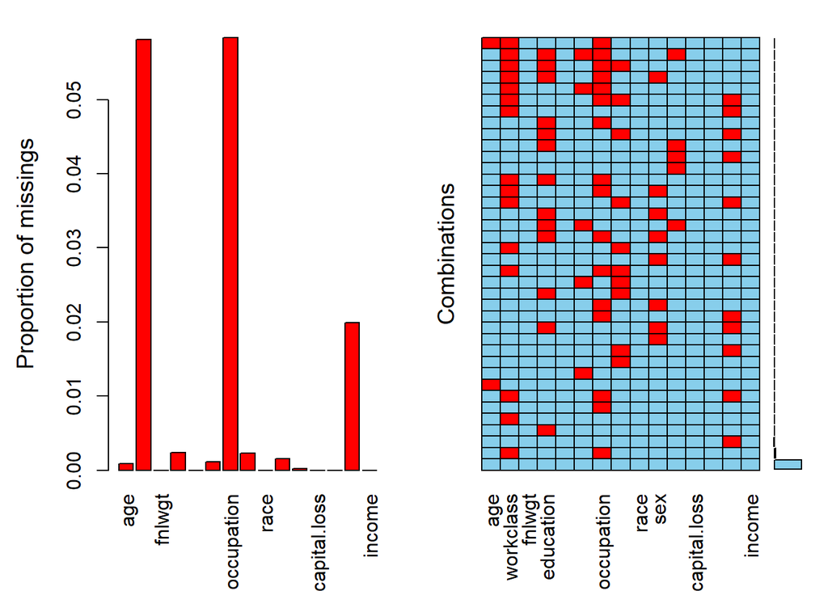

```r
aggr(df)
```

6. Approach 1 to handle NAs: remove all rows that have any NAs. Save the dataset after removing as a different data. The original data is unchanged (still have NAs). How many rows left after removing?

```r
df1 <- drop_na(df)
df1
```

```
## # A tibble: 29,865 × 15
##      age workclass      fnlwgt education education.num marital.status occupation
##    <dbl> <chr>           <dbl> <chr>             <dbl> <chr>          <chr>
##  1    82 Private        132870 HS-grad               9 Widowed        Exec-mana…
##  2    54 Private        140359 7th-8th               4 Divorced       Machine-o…
##  3    41 Private        264663 Some-col…            10 Separated      Prof-spec…
##  4    34 Private        216864 HS-grad               9 Divorced       Other-ser…
##  5    38 Private        150601 10th                  6 Separated      Adm-cleri…
##  6    74 State-gov       88638 Doctorate            16 Never-married  Prof-spec…
##  7    68 Federal-gov    422013 HS-grad               9 Divorced       Prof-spec…
##  8    45 Private        172274 Doctorate            16 Divorced       Prof-spec…
##  9    38 Self-emp-not-… 164526 Prof-sch…            15 Never-married  Prof-spec…
## 10    52 Private        129177 Bachelors            13 Widowed        Other-ser…
## # ℹ 29,855 more rows
## # ℹ 8 more variables: relationship <chr>, race <chr>, sex <chr>,
## #   capital.gain <dbl>, capital.loss <dbl>, hours.per.week <dbl>,
## #   native.country <chr>, income <chr>
```

```r
colSums(is.na(df1))
```

```
##            age      workclass         fnlwgt      education  education.num
##              0              0              0              0              0
## marital.status     occupation   relationship           race            sex
##              0              0              0              0              0
##   capital.gain   capital.loss hours.per.week native.country         income
##              0              0              0              0              0
```

**29,865 rows are left after removing the ones with NAs.**

7. Approach 2 to handle NAs: Fill all the NAs with the previous or next value. (Hint: Using `fill` function). Save the dataset after filling as a different data. The original data is unchanged (still have NAs).

```r
df2 <- df |> fill(age, workclass, education, marital.status, occupation, relationship, sex, capital.gain, native.country, .direction = 'updown')
df2
```

```
## # A tibble: 32,561 × 15
##      age workclass   fnlwgt education    education.num marital.status occupation
##    <dbl> <chr>        <dbl> <chr>                <dbl> <chr>          <chr>
##  1    90 Private      77053 HS-grad                  9 Widowed        Exec-mana…
##  2    82 Private     132870 HS-grad                  9 Widowed        Exec-mana…
##  3    66 Private     186061 Some-college            10 Widowed        Machine-o…
##  4    54 Private     140359 7th-8th                  4 Divorced       Machine-o…
##  5    41 Private     264663 Some-college            10 Separated      Prof-spec…
##  6    34 Private     216864 HS-grad                  9 Divorced       Other-ser…
##  7    38 Private     150601 10th                     6 Separated      Adm-cleri…
##  8    74 State-gov    88638 Doctorate               16 Never-married  Prof-spec…
##  9    68 Federal-gov 422013 HS-grad                  9 Divorced       Prof-spec…
## 10    41 Private      70037 Some-college            10 Never-married  Craft-rep…
## # ℹ 32,551 more rows
## # ℹ 8 more variables: relationship <chr>, race <chr>, sex <chr>,
## #   capital.gain <dbl>, capital.loss <dbl>, hours.per.week <dbl>,
## #   native.country <chr>, income <chr>
```

```r
colSums(is.na(df2))
```

```
##            age      workclass         fnlwgt      education  education.num
##              0              0              0              0              0
## marital.status     occupation   relationship           race            sex
##              0              0              0              0              0
##   capital.gain   capital.loss hours.per.week native.country         income
##              0              0              0              0              0
```

8. Approach 3 to handle NAs: For numeric variable, replace the NAs by the median. For categorical variables, replace the NAs to the majority.

```r
# Get classes of each column
sapply(df, class)
```

```
##            age      workclass         fnlwgt      education  education.num
##      "numeric"    "character"      "numeric"    "character"      "numeric"
## marital.status     occupation   relationship           race            sex
##    "character"    "character"    "character"    "character"    "character"
##   capital.gain   capital.loss hours.per.week native.country         income
##      "numeric"      "numeric"      "numeric"    "character"    "character"
```

```r
# Numeric
median_age <- median(df$age, na.rm = TRUE)
median_capital_gain <- median(df$capital.gain, na.rm = TRUE)


# Categorical
majority_workclass <- names(which.max(table(df$workclass)))
majority_education <- names(which.max(table(df$education)))
majority_marital_status <- names(which.max(table(df$marital.status)))
majority_occupation <- names(which.max(table(df$occupation)))
majority_relationship <- names(which.max(table(df$relationship)))
majority_sex <- names(which.max(table(df$sex)))
majority_native_country <- names(which.max(table(df$native.country)))
```

```r
df3 <- df
```

```r
df3$age <- replace_na(df3$age, median_age)
df3$capital.gain <- replace_na(df3$age, median_capital_gain)
df3$workclass <- replace_na(df3$age, majority_workclass)
df3$education <- replace_na(df3$age, majority_education)
df3$marital.status <- replace_na(df3$age, majority_marital_status)
df3$occupation <- replace_na(df3$age, majority_occupation)
df3$relationship <- replace_na(df3$age, majority_relationship)
df3$sex <- replace_na(df3$age, majority_sex)
df3$native.country <- replace_na(df3$age, majority_native_country)

df3
```

```
## # A tibble: 32,561 × 15
##      age workclass fnlwgt education education.num marital.status occupation
##    <dbl>     <dbl>  <dbl>     <dbl>         <dbl>          <dbl>      <dbl>
##  1    90        90  77053        90             9             90         90
##  2    82        82 132870        82             9             82         82
##  3    66        66 186061        66            10             66         66
##  4    54        54 140359        54             4             54         54
##  5    41        41 264663        41            10             41         41
##  6    34        34 216864        34             9             34         34
##  7    38        38 150601        38             6             38         38
##  8    74        74  88638        74            16             74         74
##  9    68        68 422013        68             9             68         68
## 10    41        41  70037        41            10             41         41
## # ℹ 32,551 more rows
## # ℹ 8 more variables: relationship <dbl>, race <chr>, sex <dbl>,
## #   capital.gain <dbl>, capital.loss <dbl>, hours.per.week <dbl>,
## #   native.country <dbl>, income <chr>
```

```r
colSums(is.na(df3))
```

```
##            age      workclass         fnlwgt      education  education.num
##              0              0              0              0              0
## marital.status     occupation   relationship           race            sex
##              0              0              0              0              0
##   capital.gain   capital.loss hours.per.week native.country         income
##              0              0              0              0              0
```